# Fitness Case Study

Patrick Naylor

#Bellabeat Case Study

### Goal

To help grow Bellabeat’s fitness-tracking product line, I have been tasked with exploring FitBit user data to see how customers use their devices. By understanding the device usage, Bellabeat can improve its products to fill gaps that its competitors might have. The main question we are trying to answer is: What data is FitBit failing to collect?

First, we will try to understand if users use the activity tracker to keep track of their sleep and weight.

We will start by loading the packages we need to explore the data and importing data on the users’ daily sleep, weight, steps, and hourly step data

```r
library(tidyverse)
daily_sleep <- read.csv("/Users/patricknaylor/Desktop/Google Analytics Cert/fit_data/sleepDay_merged.csv")
daily_steps <- read.csv("/Users/patricknaylor/Desktop/Google Analytics Cert/fit_data/dailySteps_merged.csv")
weight_log <- read.csv("/Users/patricknaylor/Desktop/Google Analytics Cert/fit_data/weightLogInfo_merged.csv")
hr_steps <- read.csv("/Users/patricknaylor/Desktop/Google Analytics Cert/fit_data/hourlySteps_merged.csv")
```

Let’s now look and see how often users are tracking their sleep by counting how many days each user has sleep data.

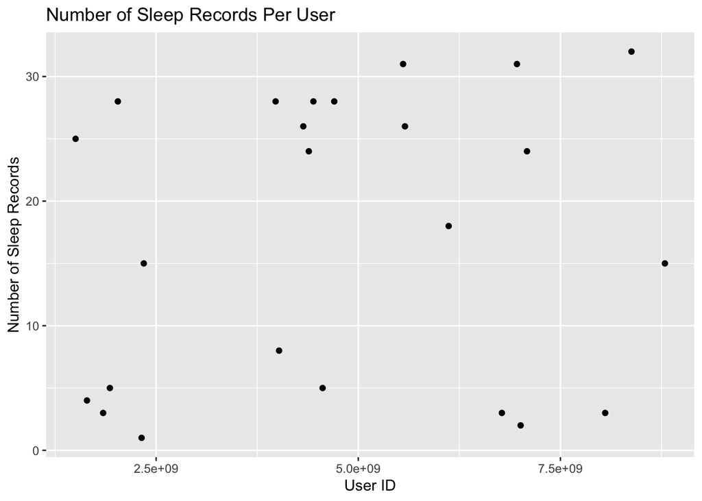

```r
daily_sleep_cnt <-
  daily_sleep %>%
  count(Id) %>%
  rename(daily_sleep_records = n)

ggplot(data = daily_sleep_cnt) +
  geom_point(mapping = aes(x = Id, y = daily_sleep_records)) +
  labs(title = "Number of Sleep Records Per User", x = "User ID", y = "Number of Sleep Records")
```

From this, we can see that while many users track their sleep every night, some are tracking much less often. Looking at the hourly step data may give us a clue as to why. First, we must clean our data and merge the different variables into one dataset.

```r
daily_steps_cnt <-
  daily_steps %>%
  count(Id) %>%
  rename(daily_step_records = n)

hr_steps_cnt <-
  hr_steps %>%
  count(Id) %>%
  rename(hr_step_records = n)

daily_rec_df = merge(daily_steps_cnt, daily_sleep_cnt, by="Id")
total_rec_df = merge(daily_rec_df, hr_steps_cnt, by="Id")

total_rec_df
```

```
##            Id daily_step_records daily_sleep_records hr_step_records
## 1  1503960366                 31                  25             717
## 2  1644430081                 30                   4             708
## 3  1844505072                 31                   3             731
## 4  1927972279                 31                   5             736
## 5  2026352035                 31                  28             736
## 6  2320127002                 31                   1             735
## 7  2347167796                 18                  15             414
## 8  3977333714                 30                  28             696
## 9  4020332650                 31                   8             732
## 10 4319703577                 31                  26             724
## 11 4388161847                 31                  24             735
## 12 4445114986                 31                  28             735
## 13 4558609924                 31                   5             736
## 14 4702921684                 31                  28             731
## 15 5553957443                 31                  31             730
## 16 5577150313                 30                  26             708
## 17 6117666160                 28                  18             660
## 18 6775888955                 26                   3             610
## 19 6962181067                 31                  31             732
## 20 7007744171                 26                   2             601
## 21 7086361926                 31                  24             733
## 22 8053475328                 31                   3             735
## 23 8378563200                 31                  32             735
## 24 8792009665                 29                  15             672
```

Let’s look at the summary statistics for this data. For this, we will use percentages based on the max possible values.

```r
rec_pct_df <-
  total_rec_df %>%
  mutate(daily_step_records = daily_step_records/31) %>%
  mutate(daily_sleep_records = daily_sleep_records/32) %>%
  mutate(hr_step_records = hr_step_records/(32*24))

summary(rec_pct_df[, c("daily_step_records", "daily_sleep_records", "hr_step_records")])
```

```
##  daily_step_records daily_sleep_records hr_step_records
##  Min.   :0.5806     Min.   :0.03125     Min.   :0.5391
##  1st Qu.:0.9677     1st Qu.:0.14844     1st Qu.:0.9180
##  Median :1.0000     Median :0.65625     Median :0.9518
##  Mean   :0.9583     Mean   :0.53776     Mean   :0.9105
##  3rd Qu.:1.0000     3rd Qu.:0.87500     3rd Qu.:0.9570
##  Max.   :1.0000     Max.   :1.00000     Max.   :0.9583
```

Users are recording step data almost every day but only sleep data about half time. Since the hourly step data is being recorded less often than the daily step data, many users likely need to sleep with their fitness trackers attached.

But just how important is getting good sleep to meeting fitness goals? Let’s see if there is a relationship between sleep and steps.

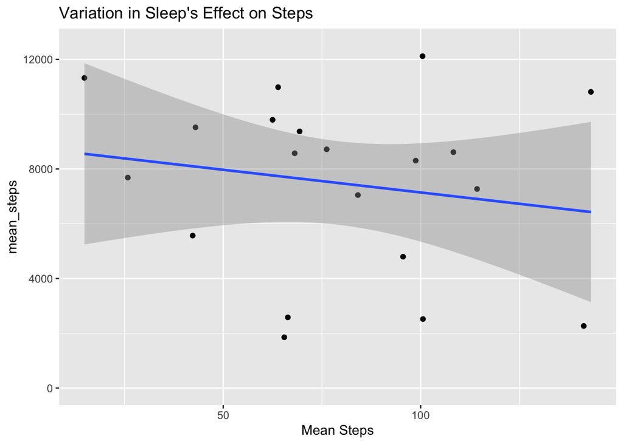

```r
daily_sleep <-
  daily_sleep %>%
  rename(Day = SleepDay)

daily_steps <-
  daily_steps %>%
  rename(Day = ActivityDay)

daily_data <-
  merge(daily_sleep, daily_steps, by=c("Id", "Day"), all.x = TRUE, all.y = TRUE)

daily_data_group <-
  daily_data %>%
  group_by(Id) %>%
  summarize(mean_steps = mean(na.omit(StepTotal)), sd_sleep = sd(na.omit(TotalMinutesAsleep))) %>%
  filter(sd_sleep < 200)

ggplot(data = daily_data_group) +
  geom_point(mapping = aes(x = sd_sleep, y = mean_steps)) +
  geom_smooth(method = lm, level = .95, mapping = aes(x =sd_sleep, y = mean_steps)) +
  coord_cartesian( ylim = c(0, 12500)) +
  labs(title = "Variation in Sleep's Effect on Steps", x = "Mean Steps", x = "std(Sleep)")
```

But just how important is getting good sleep to meeting fitness goals? Let’s see if there is a relationship between sleep and steps.

Now let’s see if users are logging their weight.

```r
weight_count <-
  weight_log %>%
  count(Id) %>%
  rename("Weight Records" = n)

weight_count
```

```
##           Id Weight Records
## 1 1503960366              2
## 2 1927972279              1
## 3 2873212765              2
## 4 4319703577              2
## 5 4558609924              5
## 6 5577150313              1
## 7 6962181067             30
## 8 8877689391             24
```

Only two users are consistently recording their weights. Let’s look into how those two users are doing to see if others should be logging more.

```r
step_weight_users <-
  daily_steps %>%
  filter(Id == 8877689391 | Id == 6962181067)

print(paste("Average steps per day for all users: ",  mean(daily_steps$StepTotal)))
```

```
## [1] "Average steps per day for all users:  7637.91063829787"
```

```r
print(paste("Average steps per day for users 8877689391 and 6962181067: ",  mean(step_weight_users$StepTotal)))
```

```
## [1] "Average steps per day for users 8877689391 and 6962181067:  12917.4193548387"
```

The users who consistently log their weights move much more throughout the day than the average user.

### Conclusion

From this data, FitBit has two problems which Bellabeat can capitalize on.

#### Problem 1: Users are not keeping their trackers on while they sleep

The data shows that many users are not keeping their trackers on while they sleep, which means they are not collecting sleep data. With sleep data it is easier for these users to understand their sleep patterns and how that affects their progress.

#### Potential Solutions:

- Send users nightly push notifications reminding users to keep their trackers on while they sleep.
- Encourage users to charge their devices during down times during the day so they are fully charged by bedtime.
- Consider launching a new product that is only meant to be worn at night and is more comfortable to be slept with than the Bellabeat Leaf or Bellabeat Time.

#### Problem 2: Users are not tracking their weights

The lack of weight data shows that users are not conserned with tracking their weights regularly. For many users, this may not be a problem as weight may not be part of their personal goals, but for many, it is. For users trying to lose or gain weight, keeping track of their progress is essential to their success.

#### Potential Solutions:

- Prompt users to select a time when they can typically record weight and send them reminders at that time to do so.
- Consider developing a smart scale that works with the app to log any weights so users do not forget automatically.

Thank you for reading through my report